# BenHuynhEDA

2025-11-05

```r
library(tidyverse)
library(dplyr)
library(tidyr)
library(GGally)
#install.packages("ggforce")
library(ggforce)
```

```r
library(corrplot)
bat <- read_csv("C:/Users/BenAH/Downloads/stat170proj/team_stan_bat.csv")
field <- read_csv("team_field.csv")
pitch <- read_csv("team_stan_pitch.csv")
pos <- read_csv("wins_above_avg_pos.csv")
head(bat)
```

```
## # A tibble: 6 × 29
##   Tm         `#Bat` BatAge `R/G`     G    PA    AB     R     H  `2B`  `3B`    HR
##   <chr>       <dbl>  <dbl> <dbl> <dbl> <dbl> <dbl> <dbl> <dbl> <dbl> <dbl> <dbl>
## 1 Arizona D…     51   28.6  5.47   162  6284  5522   886  1452   271    37   211
## 2 Atlanta B…     55   29.3  4.35   162  6075  5481   704  1333   273    15   213
## 3 Baltimore…     60   26.9  4.85   162  6176  5567   786  1391   262    33   235
## 4 Boston Re…     57   27.3  4.64   162  6192  5577   751  1404   311    30   194
## 5 Chicago C…     56   27.8  4.54   162  6116  5441   736  1318   253    29   170
## 6 Chicago W…     63   27.8  3.13   162  5869  5383   507  1187   226     9   133
## # ℹ 17 more variables: RBI <dbl>, SB <dbl>, CS <dbl>, BB <dbl>, SO <dbl>,
## #   BA <dbl>, OBP <dbl>, SLG <dbl>, OPS <dbl>, `OPS+` <dbl>, TB <dbl>,
## #   GDP <dbl>, HBP <dbl>, SH <dbl>, SF <dbl>, IBB <dbl>, LOB <dbl>
```

```r
head(field)
```

```
## # A tibble: 6 × 19
##   Tm        `#Fld` `RA/G` DefEff     G    GS    CG   Inn    Ch    PO     A     E
##   <chr>      <dbl>  <dbl>  <dbl> <dbl> <dbl> <dbl> <dbl> <dbl> <dbl> <dbl> <dbl>
## 1 Arizona …     50   4.86  0.682   162  1458  1096 12990  5848  4330  1456    62
## 2 Atlanta …     54   3.75  0.689   162  1458  1173 12990  5834  4330  1436    68
## 3 Baltimor…     58   4.31  0.704   162  1458  1084 12978  5743  4326  1336    81
## 4 Boston R…     57   4.61  0.693   162  1458   974 13074  5922  4358  1449   115
## 5 Chicago …     56   4.13  0.705   162  1458  1083 12891  5722  4297  1349    76
## 6 Chicago …     63   5.02  0.685   162  1458  1145 12780  5626  4260  1276    90
## # ℹ 7 more variables: DP <dbl>, `Fld%` <dbl>, Rtot <dbl>, `Rtot/yr` <dbl>,
## #   Rdrs <dbl>, `Rdrs/yr` <dbl>, Rgood <dbl>
```

```r
head(pitch)
```

```
## # A tibble: 6 × 36
##   Tm          `#P`  PAge `RA/G`     W     L `W-L%`   ERA     G    GS    GF    CG
##   <chr>      <dbl> <dbl>  <dbl> <dbl> <dbl>  <dbl> <dbl> <dbl> <dbl> <dbl> <dbl>
## 1 Arizona D…    33  28.6   4.86    89    73  0.549  4.62   162   162   162     0
## 2 Atlanta B…    30  31.5   3.75    89    73  0.549  3.49   162   162   160     2
## 3 Baltimore…    34  29.6   4.31    91    71  0.562  3.94   162   162   162     0
## 4 Boston Re…    35  29.5   4.61    81    81  0.5    4.04   162   162   161     1
## 5 Chicago C…    36  29.2   4.13    83    79  0.512  3.78   162   162   161     1
## 6 Chicago W…    35  27.7   5.02    41   121  0.253  4.67   162   162   162     0
## # ℹ 24 more variables: tSho <dbl>, cSho <dbl>, SV <dbl>, IP <dbl>, H <dbl>,
## #   R <dbl>, ER <dbl>, HR <dbl>, BB <dbl>, IBB <dbl>, SO <dbl>, HBP <dbl>,
## #   BK <dbl>, WP <dbl>, BF <dbl>, `ERA+` <dbl>, FIP <dbl>, WHIP <dbl>,
## #   H9 <dbl>, HR9 <dbl>, BB9 <dbl>, SO9 <dbl>, `SO/W` <dbl>, LOB <dbl>
```

```r
head(pos)
```

```
## # A tibble: 6 × 18
##      Rk Tm      Wins_Abv_Avg `All P`    SP    RP `Non-P`     C  `1B`  `2B`  `3B`
##   <dbl> <chr>          <dbl>   <dbl> <dbl> <dbl>   <dbl> <dbl> <dbl> <dbl> <dbl>
## 1     1 Philad…         15.3     6     5.3   0.7     9.3   1.9   2.9   0.7   1.1
## 2     2 New Yo…         13.7     3.3   3.6  -0.4    10.4   0.9  -3.2  -0.3   0.2
## 3     3 Los An…         13.1    -6.6  -3.5  -3.1    19.7   1.8   2.5   1     1.7
## 4     4 Atlant…         12.5    12.3   8.5   3.8     0.2   0.3   1.6  -0.8   1.8
## 5     5 Milwau…          9.9     3.6   0.7   3       6.3   2    -2.4   2.2   0.5
## 6     6 Baltim…          9.8     3.3   1.5  -3.2    11.6   0.9   0.7  -0.1   0.4
## # ℹ 7 more variables: SS <dbl>, LF <dbl>, CF <dbl>, RF <dbl>, `OF (All)` <dbl>,
## #   DH <dbl>, PH <dbl>
```

```r
data <- read_csv("combined_teams.csv")
head(data)
```

```
## # A tibble: 6 × 89
##   Tm       `#Bat` BatAge `R/G`    PA    AB R_Bat H_Bats `2B_Bat` `3B_Bat` HR_Bat
##   <chr>     <dbl>  <dbl> <dbl> <dbl> <dbl> <dbl>  <dbl>    <dbl>    <dbl>  <dbl>
## 1 Arizona…     51   28.6  5.47  6284  5522   886   1452      271       37    211
## 2 Atlanta…     55   29.3  4.35  6075  5481   704   1333      273       15    213
## 3 Baltimo…     60   26.9  4.85  6176  5567   786   1391      262       33    235
## 4 Boston …     57   27.3  4.64  6192  5577   751   1404      311       30    194
## 5 Chicago…     56   27.8  4.54  6116  5441   736   1318      253       29    170
## 6 Chicago…     63   27.8  3.13  5869  5383   507   1187      226        9    133
## # ℹ 78 more variables: RBI <dbl>, SB <dbl>, CS <dbl>, BB_Bat <dbl>,
## #   SO_Bat <dbl>, BA <dbl>, OBP <dbl>, SLG <dbl>, OPS <dbl>, `OPS+` <dbl>,
## #   TB <dbl>, GDP <dbl>, HBP_Bat <dbl>, SH <dbl>, SF <dbl>, IBB_Bat <dbl>,
## #   LOB_Bat <dbl>, `#Fld` <dbl>, `RA/G_P` <dbl>, DefEff <dbl>, CG_F <dbl>,
## #   Inn <dbl>, Ch <dbl>, PO <dbl>, A <dbl>, E <dbl>, DP <dbl>, `Fld%` <dbl>,
## #   Rtot <dbl>, `Rtot/yr` <dbl>, Rdrs <dbl>, `Rdrs/yr` <dbl>, Rgood <dbl>,
## #   `#P` <dbl>, PAge <dbl>, W <dbl>, ERA <dbl>, tSho <dbl>, cSho <dbl>, …
```

1. Set Seed and Split Test/Train

```r
set.seed(123)

n <- nrow(data)
train_index <- sample(1:n, size = 0.7 * n)
train_data <- data[train_index, ]
test_data  <- data[-train_index, ]
```

```r
y_var <- "W"

correlations <- train_data %>%
  select(where(is.numeric)) %>%
  summarise(across(-all_of(y_var),
                   ~ cor(.x, .data[[y_var]], use = "complete.obs"))) %>%
  pivot_longer(everything(), names_to = "Variable", values_to = "Correlation") %>%
  arrange(desc(abs(Correlation)))

correlations
```

```
## # A tibble: 87 × 2
##    Variable     Correlation
##    <chr>              <dbl>
##  1 Wins_Abv_Avg       0.931
##  2 Rk                -0.893
##  3 H9                -0.839
##  4 Non-P              0.824
##  5 HitAllow          -0.811
##  6 ERA               -0.808
##  7 RA/G_P            -0.807
##  8 R_P               -0.805
##  9 ER                -0.801
## 10 DefEff             0.765
## # ℹ 77 more rows
```

2. Data Description

```r
dim(train_data)
```

```
## [1] 21 89
```

Source : https://www.baseball-reference.com/leagues/majors/2024.shtml

Context: Statistics Gatheredf from the 30 MLB teams during the 2024 Season

(All taken from MLB Website) #Bat – Number of Players used in Games BatAge – Batters’ average age Weighted by AB + Games Played R/G – Runs Scored Per Game G – Games Played or Pitched PA – Plate Appearances When available, we use actual plate appearances from play-by-play game accounts Otherwise estimated using AB + BB + HBP + SF + SH, which excludes catcher interferences. When this color click for a summary of each PA. AB – At Bats R – Runs Scored/Allowed H – Hits/Hits Allowed HR – Home Runs Hit/Allowed RBI – Runs Batted In SB – Stolen Bases CS – Caught Stealing BB – Bases on Balls/Walks SO – Strikeouts BA – Hits/At Bats OBP – (H + BB + HBP)/(At Bats + BB + HBP + SF) For recent years, leaders need 3.1 PA per team game played SLG – Total Bases/At Bats or (1B + 2*2B + 3*3B + 4*HR)/AB For recent years, leaders need 3.1 PA per team game played OPS – On-Base + Slugging Percentages For recent years, leaders need 3.1 PA per team game played OPS+ – OPS+ 100*[OBP/lg OBP + SLG/lg SLG - 1] Adjusted to the player’s ballpark(s) TB – Total Bases Singles + 2 x Doubles + 3 x Triples + 4 x Home Runs. GDP – Double Plays Grounded Into Only includes standard 6-4-3, 4-3, etc. double plays. For gamelogs only in seasons we have play-by-play, we include triple plays as well. HBP – Times Hit by a Pitch. SH – Sacrifice Hits (Sacrifice Bunts) SF – Sacrifice Flies First tracked in 1954. IBB – Intentional Bases on Balls First tracked in 1955. LOB – Runners Left On Base #P – Number of Pitchers used in Games PAge – Pitchers’ average age Weighted by 3*GS + G + SV RA/G – Runs Allowed Per Game W – Wins L – Losses W-L% – Win-Loss Percentage W / (W + L) ERA – 9* ER / IP For recent years, leaders need 1 IP per team game played. Bold indicates lowest ERA using current stats Gold means awarded ERA title at end of year. G – Games Played or Pitched GS – Games Started GF – Games Finished CG – Complete Game tSho – Shutouts by a team No runs allowed in a game by one or more pitchers. cSho – Shutouts No runs allowed and a complete game. SV – Saves IP – Innings Pitched H – Hits/Hits Allowed R – Runs Scored/Allowed ER – Earned Runs Allowed HR – Home Runs Hit/Allowed BB – Bases on Balls/Walks IBB – Intentional Bases on Balls First tracked in 1955. SO – Strikeouts HBP – Times Hit by a Pitch. BK – Balks WP – Wild Pitches BF – Batters Faced ERA+ – ERA+ 100*[lgERA/ERA] Adjusted to the player’s ballpark(s). FIP – Fielding Independent Pitching this stat measures a pitcher’s effectiveness at preventing HR, BB, HBP and causing SO (13*HR + 3*(BB+HBP) - 2*SO)/IP + Constantlg The constant is set so that each season major-league average FIP is the same as the major-league avg ERA WHIP – (BB + H)/IP For recent years, leaders need 1 IP per team game played H9 – 9 x H / IP For recent years, leaders need 1 IP per team game played HR9 – 9 x HR / IP For recent years, leaders need 1 IP per team game played BB9 – 9 x BB / IP For recent years, leaders need 1 IP per team game played SO9 – 9 x SO / IP For recent years, leaders need 1 IP per team game played SO/W – SO/W or SO/BB For recent years, pitching leaders need 1 IP per team game played. No batting leaders computed. LOB – Runners Left On Base ALL P – All Positions SP – Start Pitcher RP – Reflief Pitcher Non-P – non-Pitcher C – Catcher 1B – 1st Base 2B – 2nd Base 3b – 3rd Base SS – ShortStop LF – Left Field CF – Center Field RF – Right Field OF(All) - Outfield(ALL) DH - Designated Hitter PH - Pinch Hitter #Fld – Number of Players used as Fielders RA/G – Runs Allowed Per Game DefEff – Defensive Efficiency Percentage of balls in play converted into outs This is an estimate based on team defensive and pitching stats. We utilize two estimates of plays made. One using innings pitched, strikeouts, double plays and outfield assists. And the other with batters faced, strikeouts, hits allowed, walks allowed, hbp, and .71 * errors committed (avg percent of errors that result in an ROE) Total plays available are plays made + hits allowed - home runs + error committed estimate. G – Games Played or Pitched GS – Games Started CG – Complete Game Inn – Innings Played in Field Ch – Defensive Chances Putouts + Assists + Errors PO – Putouts A – Assists E – Errors Committed DP – Double Plays Turned Fld% – Fielding Percentage (Putouts + Assists) / (Putouts + Assists + Errors) Rtot – Total Zone Total Fielding Runs Above Avg The number of runs above or below average the player was worth based on the number of plays made. This number combines the Rtz, Rdp, Rof, Rcatch numbers into a total defensive contribution. See the glossary section for a more complete explanation. Provided by BaseballProjection.com Rtot/yr – Total Zone Total Fielding Runs Above Avg per 1,200 Inn The number of runs above or below average the fielder was worth per 1,200 Innings (approx 135 games). This number combines the Rtz, Rdp, Rof, Rcatch numbers into a total defensive contribution. See the glossary section for a more complete explanation. Provided by BaseballProjection.com Rdrs – BIS Defensive Runs Saved Above Avg The number of runs above or below average the team was worth based on their overall defense. This number combines the individual players’ defensive runs saved as well as team-level runs saved from shifting and positioning into a total team defensive contribution. Provided by Baseball Info Solutions Rdrs/yr – BIS Defensive Runs Saved Above Avg per 1,200 Inn The number of runs above or below average the team’s fielders were worth per 1,200 Innings (approx 135 games). This number combines the Rpm, Rdp, and Rgood numbers into a total defensive contribution. For pitchers, this is set to 200 Innings. This does not include any team-level runs saved from positioning or shifting. Provided by Baseball Info Solutions Rgood – BIS Good Plays/Misplays Runs Above Avg

3. Descriptive Statistics

```r
#install.packages("skimr")
library(skimr)
skim(train_data)
```

Data summary

| Name | train_data |
| --- | --- |
| Number of rows | 21 |
| Number of columns | 89 |
| _______________________ |  |
| Column type frequency: |  |
| character | 1 |
| numeric | 88 |
| ________________________ |  |
| Group variables | None |

**Variable type: character**

| skim_variable | n_missing | complete_rate | min | max | empty | n_unique | whitespace |
| --- | --- | --- | --- | --- | --- | --- | --- |
| Tm | 0 | 1 | 12 | 20 | 0 | 21 | 0 |

**Variable type: numeric**

| skim_variable | n_missing | complete_rate | mean | sd | p0 | p25 | p50 | p75 | p100 | hist |
| --- | --- | --- | --- | --- | --- | --- | --- | --- | --- | --- |
| #Bat | 0 | 1 | 55.24 | 5.49 | 44.00 | 52.00 | 55.00 | 58.00 | 70.00 | ▂▇▇▃▁ |
| BatAge | 0 | 1 | 27.83 | 1.13 | 26.10 | 27.10 | 27.80 | 28.60 | 30.30 | ▇▇▇▃▂ |
| R/G | 0 | 1 | 4.38 | 0.37 | 3.73 | 4.15 | 4.28 | 4.60 | 5.20 | ▂▇▃▂▂ |
| PA | 0 | 1 | 6084.05 | 88.13 | 5927.00 | 6026.00 | 6067.00 | 6123.00 | 6255.00 | ▃▇▇▂▃ |
| AB | 0 | 1 | 5456.24 | 75.87 | 5310.00 | 5432.00 | 5460.00 | 5510.00 | 5577.00 | ▃▂▇▇▃ |
| R_Bat | 0 | 1 | 708.76 | 60.30 | 604.00 | 672.00 | 693.00 | 742.00 | 842.00 | ▂▇▃▂▂ |
| H_Bats | 0 | 1 | 1320.81 | 65.38 | 1195.00 | 1273.00 | 1318.00 | 1357.00 | 1448.00 | ▃▅▇▇▃ |
| 2B_Bat | 0 | 1 | 258.90 | 24.13 | 220.00 | 243.00 | 257.00 | 267.00 | 311.00 | ▃▇▇▃▂ |
| 3B_Bat | 0 | 1 | 23.10 | 8.08 | 13.00 | 17.00 | 23.00 | 29.00 | 47.00 | ▇▅▅▁▁ |
| HR_Bat | 0 | 1 | 182.86 | 27.73 | 135.00 | 165.00 | 179.00 | 194.00 | 237.00 | ▂▅▇▁▂ |
| RBI | 0 | 1 | 676.67 | 60.59 | 564.00 | 642.00 | 661.00 | 702.00 | 815.00 | ▂▇▃▂▂ |
| SB | 0 | 1 | 119.76 | 43.29 | 65.00 | 91.00 | 106.00 | 143.00 | 223.00 | ▇▇▆▁▂ |
| CS | 0 | 1 | 32.43 | 13.43 | 19.00 | 24.00 | 26.00 | 43.00 | 73.00 | ▇▁▂▁▁ |
| BB_Bat | 0 | 1 | 499.48 | 57.97 | 403.00 | 473.00 | 490.00 | 496.00 | 672.00 | ▂▇▁▁▁ |
| SO_Bat | 0 | 1 | 1397.71 | 128.76 | 1176.00 | 1318.00 | 1382.00 | 1485.00 | 1625.00 | ▃▇▅▇▃ |
| BA | 0 | 1 | 0.24 | 0.01 | 0.22 | 0.23 | 0.24 | 0.25 | 0.26 | ▃▇▇▅▂ |
| OBP | 0 | 1 | 0.31 | 0.01 | 0.30 | 0.30 | 0.31 | 0.32 | 0.34 | ▇▂▃▁▂ |
| SLG | 0 | 1 | 0.40 | 0.02 | 0.37 | 0.38 | 0.39 | 0.42 | 0.45 | ▇▇▂▅▂ |
| OPS | 0 | 1 | 0.71 | 0.03 | 0.67 | 0.69 | 0.70 | 0.73 | 0.78 | ▇▇▂▃▂ |
| OPS+ | 0 | 1 | 100.19 | 9.82 | 87.00 | 92.00 | 100.00 | 108.00 | 120.00 | ▇▆▃▃▃ |
| TB | 0 | 1 | 2174.48 | 142.10 | 1973.00 | 2080.00 | 2139.00 | 2287.00 | 2465.00 | ▅▇▂▃▂ |
| GDP | 0 | 1 | 105.05 | 16.55 | 71.00 | 91.00 | 105.00 | 115.00 | 138.00 | ▁▇▇▅▃ |
| HBP_Bat | 0 | 1 | 69.29 | 18.41 | 49.00 | 55.00 | 64.00 | 78.00 | 116.00 | ▇▅▂▂▁ |
| SH | 0 | 1 | 13.62 | 5.91 | 4.00 | 10.00 | 14.00 | 17.00 | 26.00 | ▅▇▇▃▂ |
| SF | 0 | 1 | 42.38 | 6.40 | 30.00 | 40.00 | 43.00 | 47.00 | 57.00 | ▃▃▇▅▁ |
| IBB_Bat | 0 | 1 | 17.67 | 7.52 | 7.00 | 12.00 | 15.00 | 20.00 | 33.00 | ▇▇▃▁▅ |
| LOB_Bat | 0 | 1 | 1082.90 | 48.90 | 978.00 | 1059.00 | 1099.00 | 1113.00 | 1149.00 | ▃▂▃▇▅ |
| #Fld | 0 | 1 | 54.62 | 5.32 | 44.00 | 52.00 | 55.00 | 57.00 | 70.00 | ▂▅▇▁▁ |
| RA/G_P | 0 | 1 | 4.40 | 0.45 | 3.75 | 4.12 | 4.31 | 4.56 | 5.73 | ▇▇▆▁▁ |
| DefEff | 0 | 1 | 0.70 | 0.01 | 0.67 | 0.69 | 0.70 | 0.70 | 0.72 | ▂▂▅▇▁ |

[output cut: 58 more lines]

1. variabe: shape w/, skew if any, ~mean, f~ median
2. approx norm, slight right skew, 55.24, 55
3. norm, 27.83, 27.8
4. not norm, slight right skew, 4.38, 4.28
5. norm, 6085, 6067
6. norm, 5456, 5460
7. not norm, right skew, 1321, 1318
8. not norm, right skew, 259, 257
9. not norm, right skew, 259, 257
10. not norm, right skew, 23, 23
11. not norm, right skew, 183, 179
12. not norm, right skew, 677, 661
13. not norm, right skew 677, 661
14. not norm, righ skew, 32, 26
15. norm, 499, 490
16. not normal, right skew, 1398, 1382
17. norm, 0.242, 0.242
18. norm, 0.311, 0.309
19. approx norm, right skew, 0.398, 0.393
20. approx norm, right skew, 0.710, 0.703
21. norm, 100.19, 100
22. not norm, right skew, 2174, 2139
23. not norm, right skew, 105, 105
24. not norm, right skew, 69, 64
25. not norm, right skew, 14, 14
26. norm, 42, 43
27. not norm, right skew, 18, 15
28. norm, 1083, 1099
29. norm, 55, 55
30. approx norm, right skew, 4.4, 4.31
31. norm, 0.698, 0.702
32. norm, 1076, 1080
33. norm, 12940, 12936
34. norm, 5779, 5771
35. norm, 4314, 4312
36. norm, 1378, 1366
37. approx norm, slight right skew, 88, 87
38. not norm, right skew, 122, 123
39. norm, 0.985, 0.985
40. not norm, left skew, -0.62, 4
41. not norm, still symmetric, -0.048, 0
42. not norm, slight left skew, -1.43, -3
43. not norm, still symmetric, 0, 0
44. not norm, slight left skew, -0.81, -1
45. norm, 33, 32
46. norm, 28.9, 28.9
47. norm, 81.2, 82 47, approx norm, right skew, 4.07, 4.04
48. not norm, right skew, 10.3, 11
49. not norm, right skew, 0.43, 0
50. approx norm, right skew, 43, 40
51. norm, 1437, 1437
52. norm, 1324, 2303
53. norm, 713, 699
54. norm, 650, 648
55. norm, 182, 181,
56. norm, 494, 492
57. nor norm right skew, 15, 14
58. norm, 1371, 1371
59. not norm, right skew, 68, 66
60. not norm, right skew, 68, 66
61. approx norm, right skew, 48, 46
62. norm, 6080, 6078
63. norm, 101, 101
64. norm, 4.07, 4.04
65. norm, 1.26, 1.25
66. norm, 8.29, 8.2
67. norm, 1.13, 1.1
68. norm, 3.1, 3.1
69. norm, 8.59. 8.6
70. norm 2.81, 2.78
71. norm, 1074, 1080
72. not norm, right skew, 16.6, 17
73. not norm, left skew, -0.46, 0.4
74. not norm, left skew, -0.27, 0
75. approx norm, right skew, 0.53, 1
76. not norm, left skew, -1.03, -0.9
77. not norm, left skew, -0.31, -0.6
78. not norm, left skew, -0.21, -0.2
79. not norm, left skew, -1.03, -1 80/ norm, -0.2, -0.3
80. norm, 0.048, 0.2
81. not norm, right skew, 1.53, 1.6
82. norm, -0.18, -0.1
83. approx norm, right skew, 0.47, -0.2
84. norm, -0.16, -0.3
85. not norm, right skew, 0.13, -0.8
86. norm, 0.009, -0.3
87. not norm, left skew, -0.6, -0.6
88. Visual Explanation

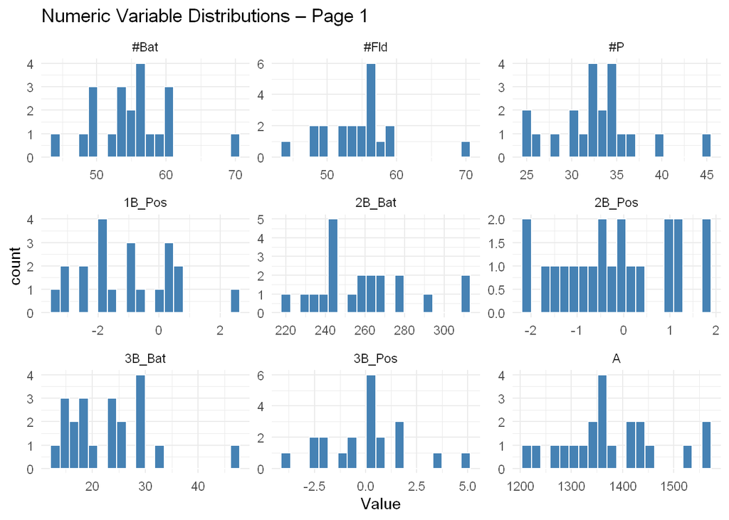

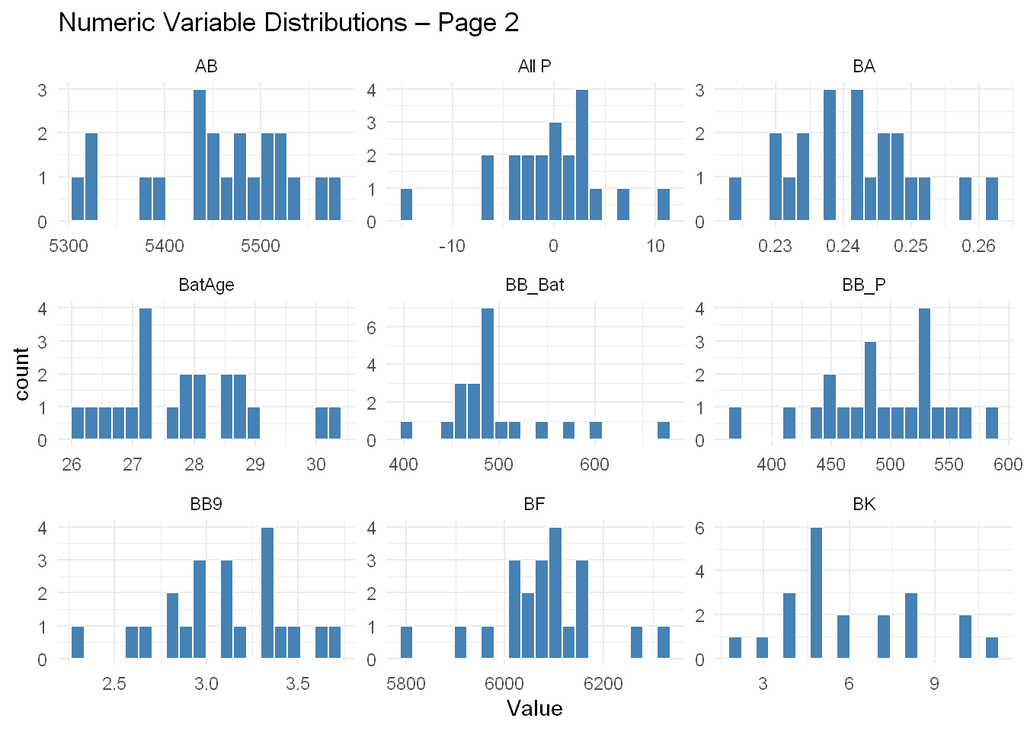

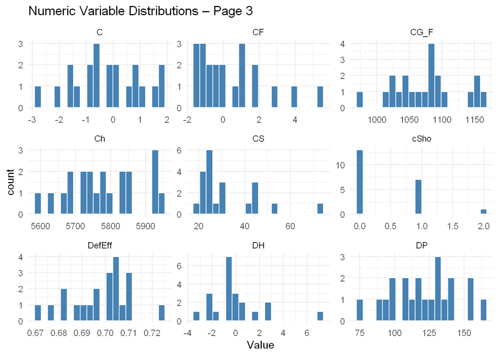

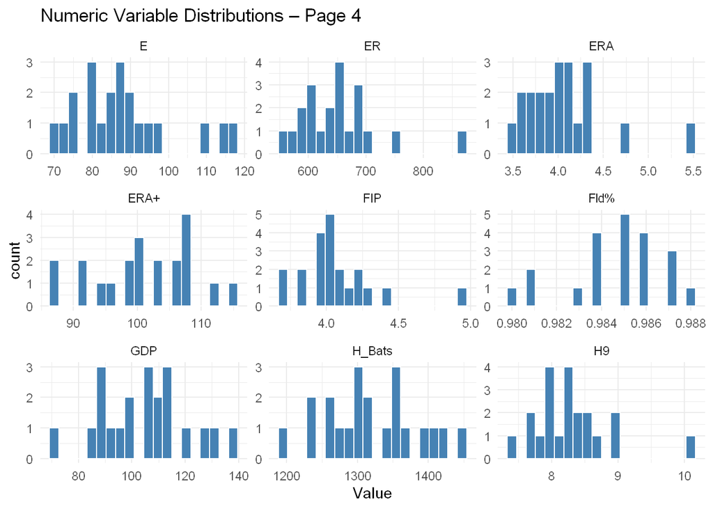

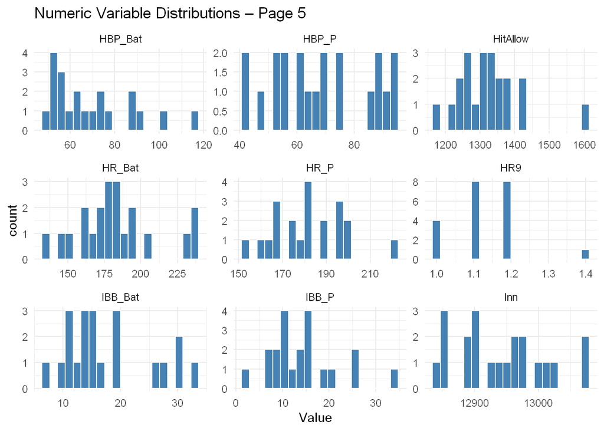

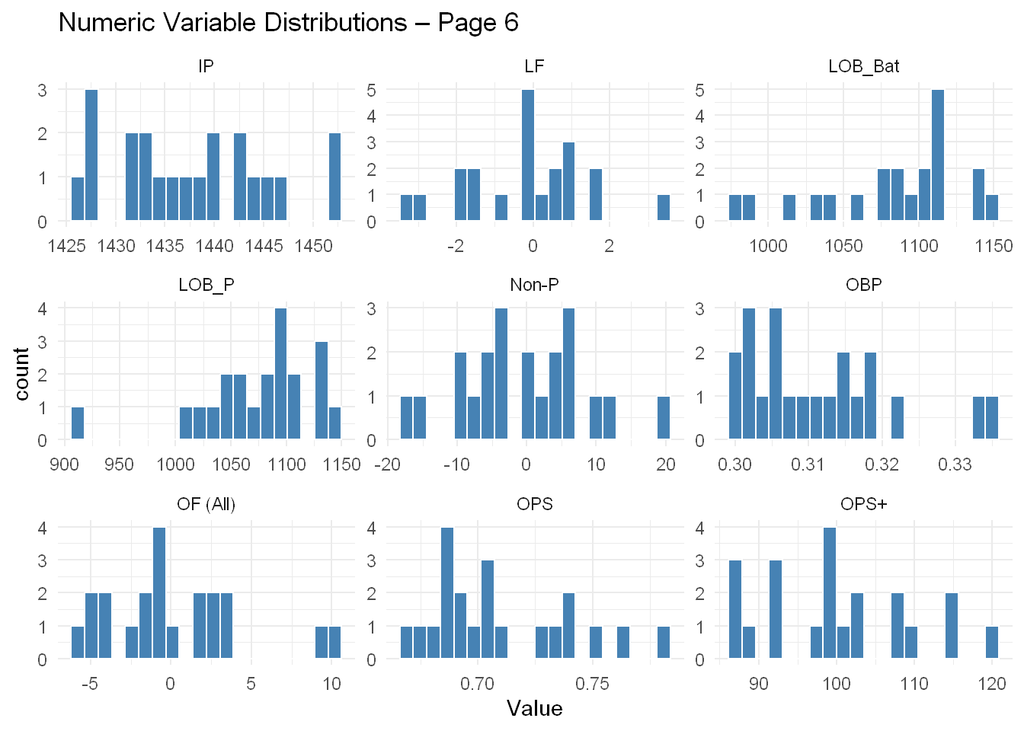

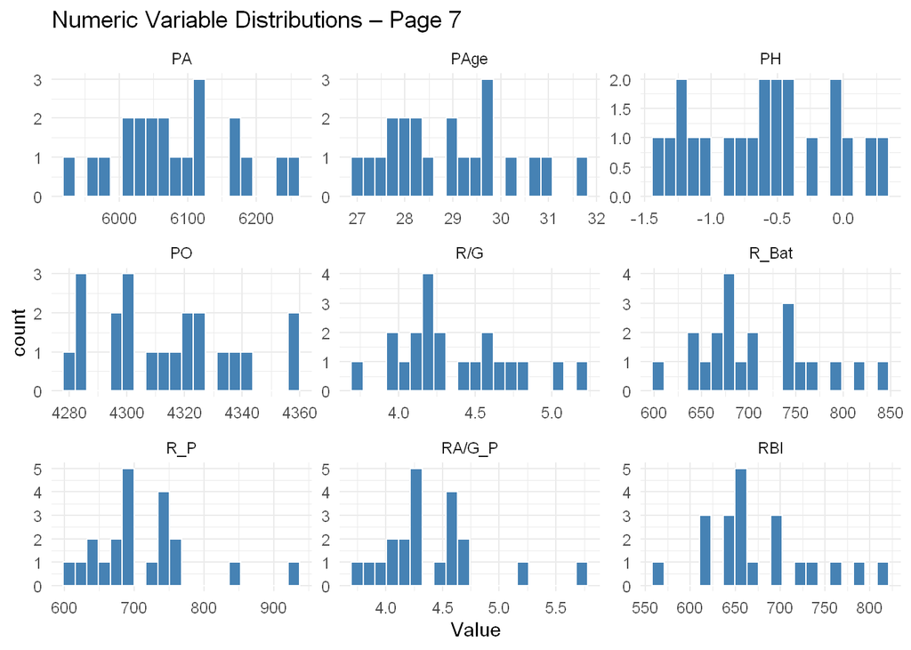

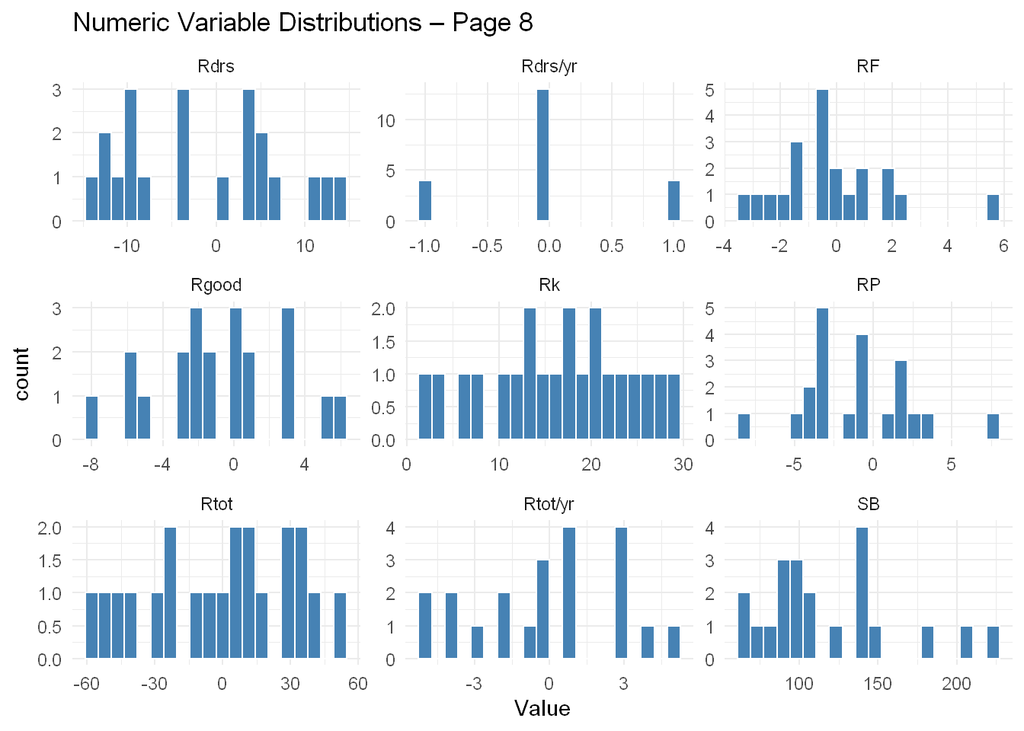

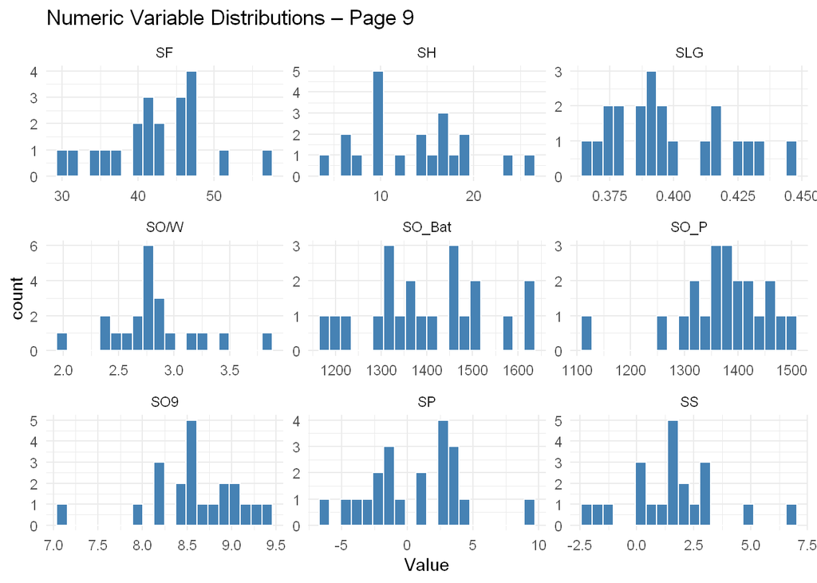

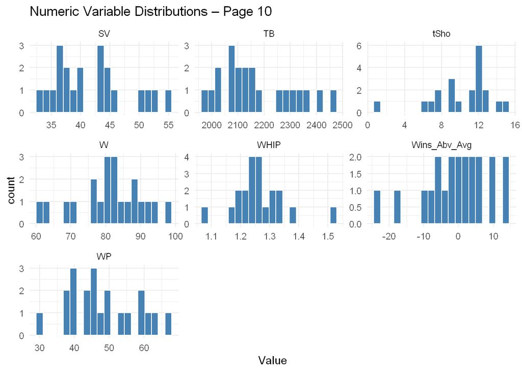

```r
long_data <- train_data %>%
  select(where(is.numeric)) %>%
  pivot_longer(everything(), names_to = "Variable", values_to = "Value")


n_vars <- length(unique(long_data$Variable))


plots_per_page <- 9
n_pages <- ceiling(n_vars / plots_per_page)


for (i in 1:n_pages) {
  p <- ggplot(long_data, aes(x = Value)) +
    geom_histogram(bins = 20, fill = "steelblue", color = "white") +
    facet_wrap_paginate(~ Variable, scales = "free", ncol = 3, nrow = 3, page = i) +
    labs(title = paste("Numeric Variable Distributions – Page", i)) +
    theme_minimal()

  print(p)
}
```

```r
numeric_data <- train_data %>%
  select(where(is.numeric))

cor_matrix <- cor(numeric_data, use = "pairwise.complete.obs")
#cor_matrix
high_corr <- as.data.frame(as.table(cor_matrix)) %>%
  rename(Var1 = Var1, Var2 = Var2, correlation = Freq) %>%
  filter(Var1 != Var2) %>%
  mutate(pair = paste(pmin(as.character(Var1), as.character(Var2)),
                      pmax(as.character(Var1), as.character(Var2)), sep = " - ")) %>%
  distinct(pair, .keep_all = TRUE) %>%
  filter(abs(correlation) > 0.7) %>%              #
  arrange(desc(abs(correlation)))

high_corr
```

```
##             Var1         Var2 correlation                    pair
## 1             PO          Inn   1.0000000                Inn - PO
## 2            R_P       RA/G_P   0.9998419            R_P - RA/G_P
## 3          R_Bat          R/G   0.9996615             R/G - R_Bat
## 4             IP          Inn   0.9996330                Inn - IP
## 5             IP           PO   0.9996330                 IP - PO
## 6             ER          ERA   0.9988255                ER - ERA
## 7            BB9         BB_P   0.9960581              BB_P - BB9
## 8             H9     HitAllow   0.9959739           H9 - HitAllow
## 9        Rtot/yr         Rtot   0.9955487          Rtot - Rtot/yr
## 10           RBI        R_Bat   0.9953190             R_Bat - RBI
## 11           SO9         SO_P   0.9952240              SO_P - SO9
## 12           RBI          R/G   0.9941974               R/G - RBI
## 13          Fld%            E  -0.9897050                E - Fld%
## 14          #Fld         #Bat   0.9876460             #Bat - #Fld
```

[output cut: 208 more lines]

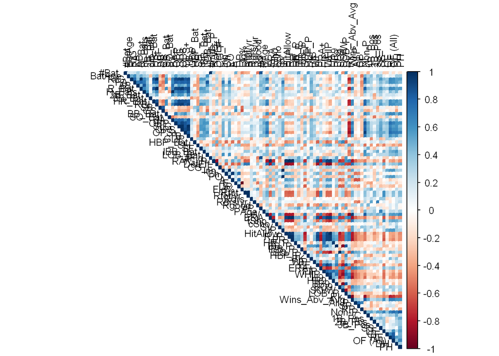

```r
options(repr.plot.width = 15, repr.plot.height = 15)
corrplot(cor_matrix, method = "color", type = "upper",
         tl.col = "black", tl.cex = 0.8)
```

There are too many variables to read on a standard correlation matrix. Instead I used chatgpt to create a table listing every pair with correlation of coefficient of 0.7 and higher. There is a lot of interaction between certain variables, as some variables might be a formula or a version of another variable(for example: Rtot and Rtot/yr which is just a yearly standardized version of Rtot or H9 which is hiter per 9 innings or hit allow which is total hits allowed). This table basically ask us to choose one variable or another as they are statistically and contextually the same.

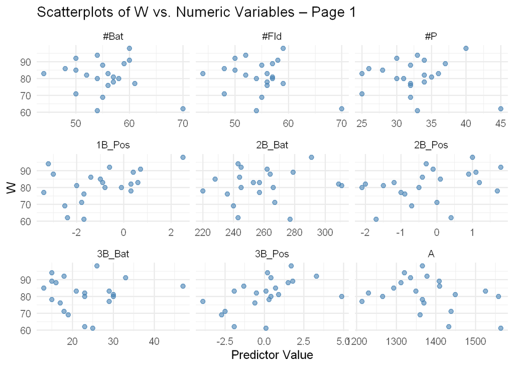

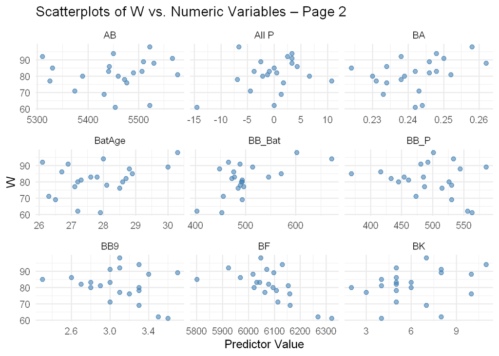

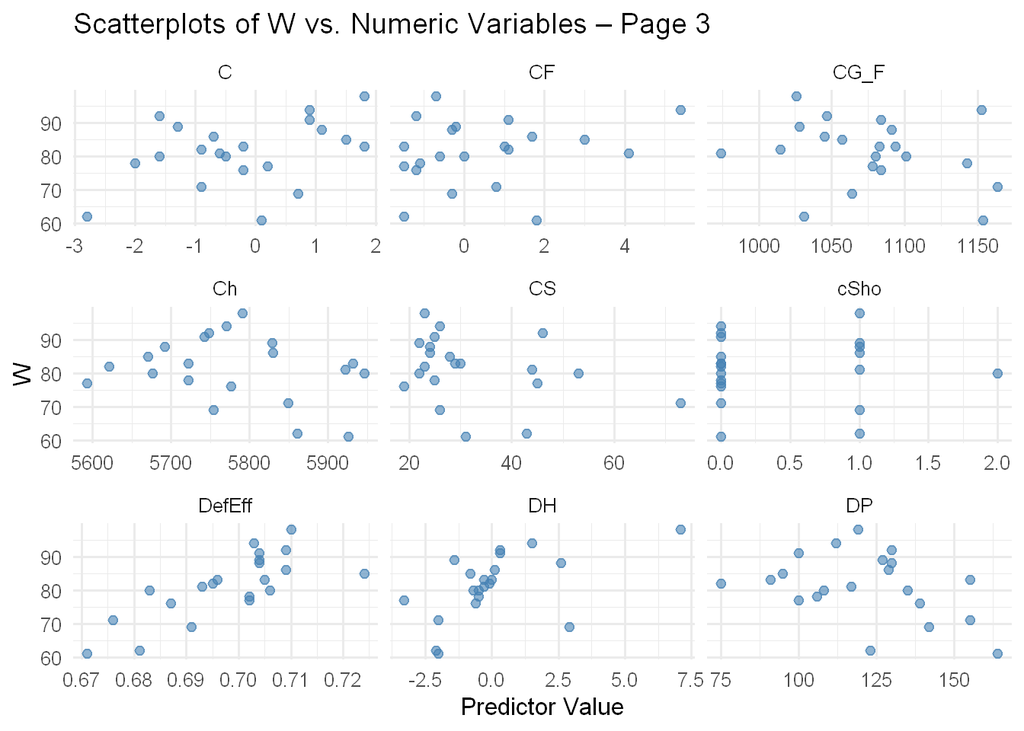

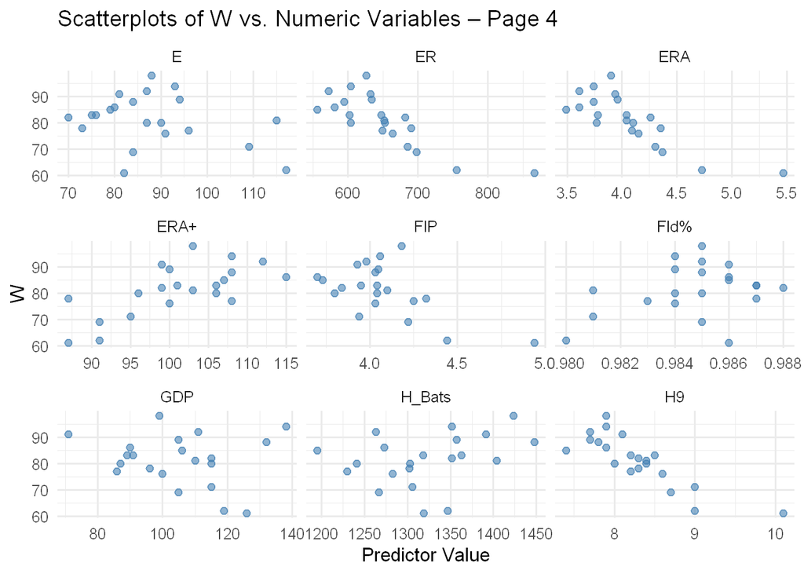

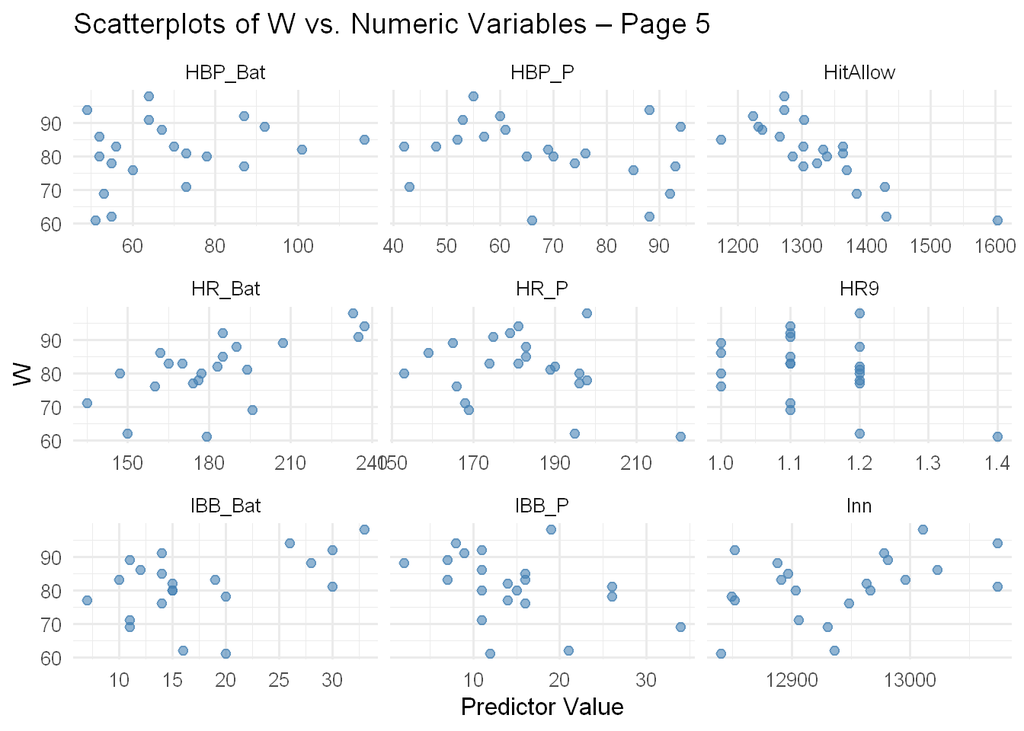

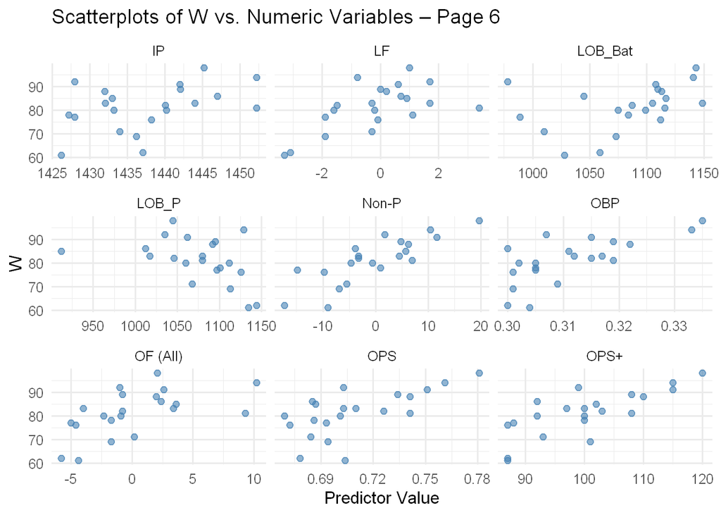

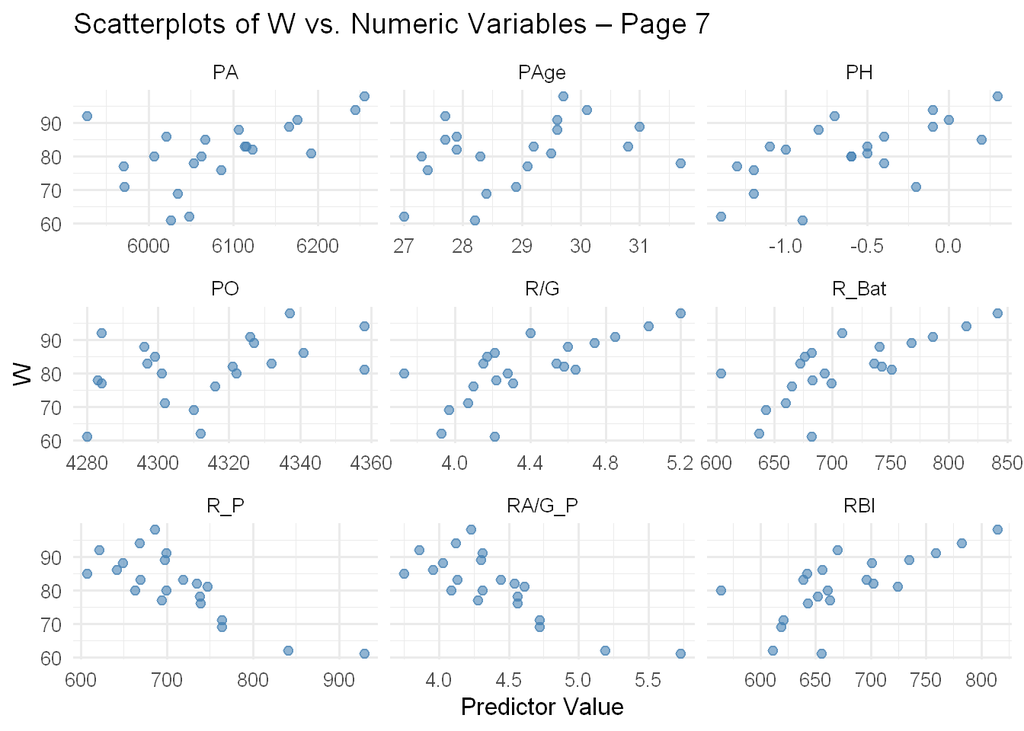

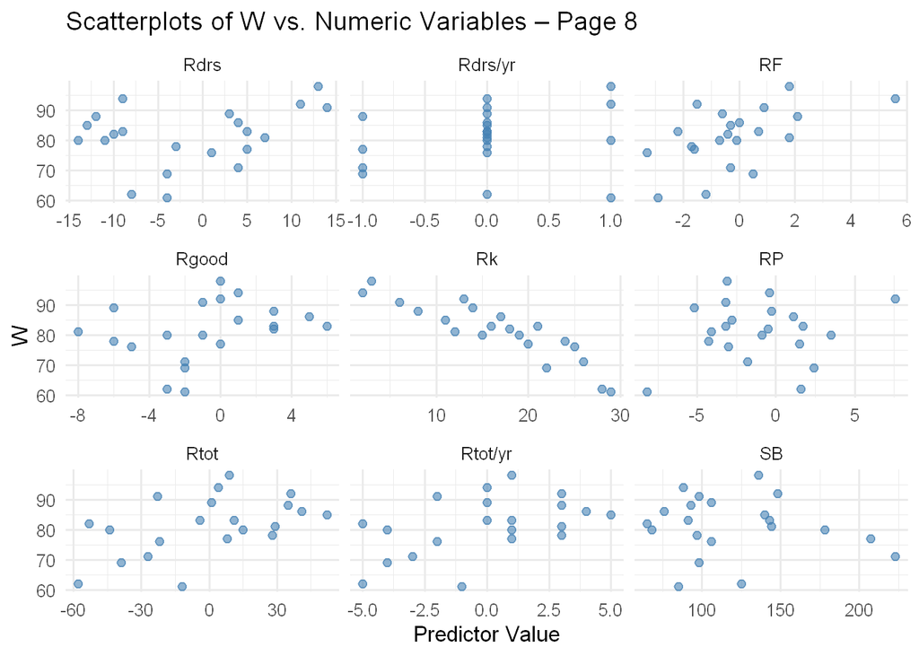

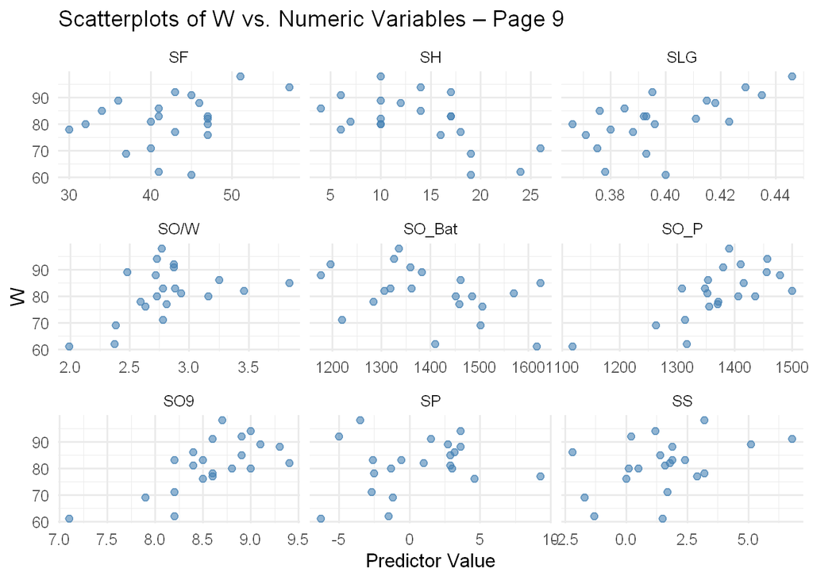

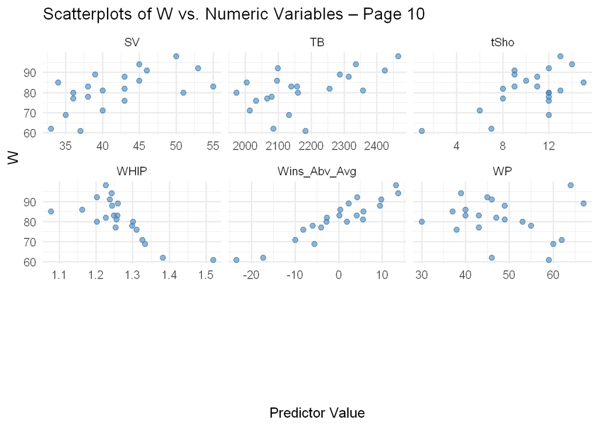

```r
long_data <- train_data %>%
  select(where(is.numeric)) %>%
  pivot_longer(cols = -all_of(y_var), names_to = "Variable", values_to = "Value")


n_vars <- length(unique(long_data$Variable))


plots_per_page <- 9
n_pages <- ceiling(n_vars / plots_per_page)

for (i in 1:n_pages) {
  p <- ggplot(long_data, aes(x = Value, y = .data[[y_var]])) +
    geom_point(alpha = 0.6, color = "steelblue", size = 2) +
    facet_wrap_paginate(~ Variable, scales = "free_x", ncol = 3, nrow = 3, page = i) +
    labs(
      title = paste("Scatterplots of", y_var, "vs. Numeric Variables – Page", i),
      x = "Predictor Value",
      y = y_var
    ) +
    theme_minimal(base_size = 12)

  print(p)
}
```

Positive Relationship~ Strong linear:DefEff, Non-P, OPS+, SV, Wins_Abv_Avg Moderate Linear:BB_Bat, DH, ERA+, HR_Bat, OF(ALL), OPS, R/G, R_Bat, RBI, SLG, SO_P, SO9, TB, tSho Weak Linear: #Fld, 1b_pos, 3b_pos, BA, C, Fld%, LF, OBP, PA, PH, RF, SP

Not Pos or Neg but Linear:#Bat, #P, 2b_Bat, A, HBP_P, IBB_BAT, IP, SS, WP No Relationship:2b_pos, 3b_BAt, AB, AllP, BatAge, BK, CF, CG_F, CS, cSho, GDP, H_Bats, HBP_Bat, HR9, PAge, PO, Rdrs, Rdrs/yr, Rgood, RP, Rtot, Rtot/yr, SB, SF, SO_Bat

(Quadratic or Parabola) Stong Curvilinear: Moderate CurvilinearL:LOB_BAT Weak Curvilinear: Ch, DP

Log Relationship ~ Negative - Strong: Moderate:R_P, RA/G Weak:

Positive - Strong: Moderate: Weak:

Nothing too suprising, only noticeable observation is that there are more, stronger or moderate linear relationships between defensive state(pitching and fielding) and wins than there are offensive stats and wins.